# Black_Final_Project_1

### CIS 512 Final Project:

#### 12/7/2022

## **Exploring the Bike Rentals Dataset in Python**

[figure not shown]

```python
import pandas as pd
hour_origin = pd.read_csv("~/Downloads/hour.csv")

%matplotlib inline
import matplotlib.pyplot as plt
plt.style.use('seaborn-whitegrid')
import seaborn as sns
sns.set()
import numpy as np
```

```python
sum(hour_origin.isnull().values.any(axis=1))
```

```
0
```

```python
hours = hour_origin.dropna()
```

```python
hours.shape
```

```
(17379, 17)
```

```python
hour_origin.shape
```

```
(17379, 17)
```

### Introduction:

##### The dataset we will be working with comes from a two-year historical log that corresponds to the years 2011 and 2012 from the Capital Bikeshare System in Washington D.C. This data is publicly available at http://capitalbikeshare.com/system-data. There are two different datasets, one measured by day and one measured by hour. We will be working with the dataset measured by hour.

##### This dataset contains information related to the number of bike rentals over the course of time. It also includes information about the time of year and the weather during which these rentals took place. The total number of rentals is further divided into two categories: registered rentals and casual rentals. There are a total of 17 columns and 17,379 rows in this set.

##### We can also see that this data does not contain any missing values. In terms of real-world value, it seems logical that we would want to find ways to maximize our bike rentals. One way to do this is to look at the timepoints where sales are the highest and lowest. A second way is to take a closer look at how various weather conditions affect the rental sales. These two factors, timepoints and weather conditions, will be the focus of our analysis.

### Exploring the Data:

```python
hours.head()
```

|  | instant | dteday | season | yr | mnth | hr | holiday | weekday | workingday | weathersit | temp | atemp | hum | windspeed | casual | registered | cnt |
| --- | --- | --- | --- | --- | --- | --- | --- | --- | --- | --- | --- | --- | --- | --- | --- | --- | --- |
| 0 | 1 | 2011-01-01 | 1 | 0 | 1 | 0 | 0 | 6 | 0 | 1 | 0.24 | 0.2879 | 0.81 | 0.0 | 3 | 13 | 16 |
| 1 | 2 | 2011-01-01 | 1 | 0 | 1 | 1 | 0 | 6 | 0 | 1 | 0.22 | 0.2727 | 0.80 | 0.0 | 8 | 32 | 40 |
| 2 | 3 | 2011-01-01 | 1 | 0 | 1 | 2 | 0 | 6 | 0 | 1 | 0.22 | 0.2727 | 0.80 | 0.0 | 5 | 27 | 32 |
| 3 | 4 | 2011-01-01 | 1 | 0 | 1 | 3 | 0 | 6 | 0 | 1 | 0.24 | 0.2879 | 0.75 | 0.0 | 3 | 10 | 13 |
| 4 | 5 | 2011-01-01 | 1 | 0 | 1 | 4 | 0 | 6 | 0 | 1 | 0.24 | 0.2879 | 0.75 | 0.0 | 0 | 1 | 1 |

```python
sum(hours.cnt)
```

```
3292679
```

```python
sum(hours.casual) / sum(hours.cnt)
```

```
0.18830168382645257
```

```python
sum(hours.registered) / sum(hours.cnt)
```

```
0.8116983161735475
```

```python
sum(hours.registered) - sum(hours.casual)
```

```
2052645
```

##### We can see here that there that the total number of rentals is 3,292,679. The total casual rentals account for only 18.8% of these rentals, whereas registered rentals count for 81.2%. We should take notice of this, as it may present an opportunity for the Capital Bikeshare System to grow its casual rentals.

##### We can make some exploratory plots to learn more about the data. First, we will create some plots that focus on rentals during various timepoints.

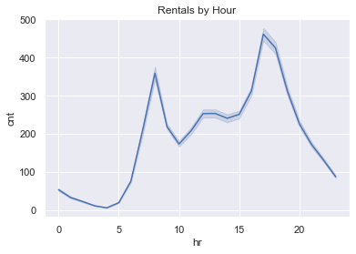

```python
sns.lineplot(data = hours, x = 'hr', y = 'cnt').set_title("Rentals by Hour")
```

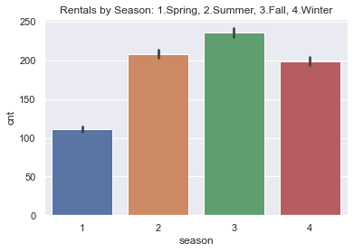

```python
sns.barplot(data = hours, x = 'season', y = 'cnt').set_title("Rentals by Season: 1.Spring, 2.Summer, 3.Fall, 4.Winter")
```

##### Next, we can take a look at the number of rentals in each month of the year. It would appear that our best sales take place between May and October, with a steep increase between April and May, and a steep decrease from October to November.

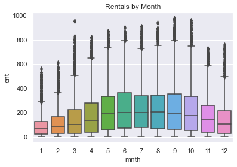

```python
sns.boxplot(x = 'mnth', y = 'cnt', data = hours).set_title("Rentals by Month")
```

##### Now, lets take a look at how weather can affect the number of rentals by looking at some scatter plots and violin plots. We will start by looking at how weather affects the total number of rentals. Notice our variable labeled "weathersit" contains values of 1 through 4. These stand for the following:

###### 1. Clear weather

###### 2. Misty weather with some clouds

###### 3. Light rain or light snow

###### 4. Heavy rain, ice pellets, thunderstorms

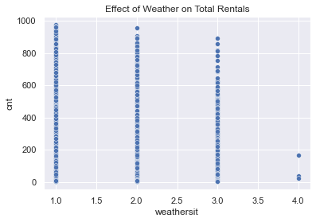

```python
sns.scatterplot(x='weathersit', y='cnt', data=hours).set_title("Effect of Weather on Total Rentals")
```

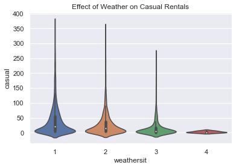

```python
sns.violinplot(x='weathersit', y='casual', data=hours, scale = 'width').set_title("Effect of Weather on Casual Rentals")
```

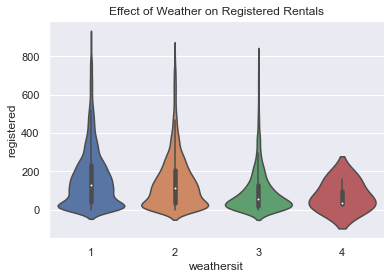

```python
sns.violinplot(x='weathersit', y='registered', data=hours, scale = 'width').set_title("Effect of Weather on Registered Rentals")
```

##### We can see that there are very few rentals during a weather level of 4, which includes heavy rain, snow, ice pellets, and thunderstorms. In addition, in the second and third plots, we can see that weather seems to have a larger impact on casual rentals than it does on registered rentals.

##### Now, we can create a PCA biplot to visualize some of the relationships between our rentals and some other weather-related variables. In order to do this, we first need to scale our data in order to better visualize our vectors.

```python
hours_X = hours[['temp', 'atemp', 'hum', 'windspeed', 'casual', 'registered', 'cnt']]
hours_y = hours['weathersit']

from sklearn.preprocessing import StandardScaler
scaler = StandardScaler()
scaler.fit(hours_X)
scaled_X = scaler.transform(hours_X)

from sklearn.decomposition import PCA
#standard scale on hours_X
pca = PCA(n_components = 7, whiten = True)
xpca = pca.fit_transform(scaled_X)

#print(pca.components_)

#print(pca.explained_variance_ratio_)

pca.mean_[:2]
```

```
array([ 1.56998913e-16, -1.83165398e-16])
```

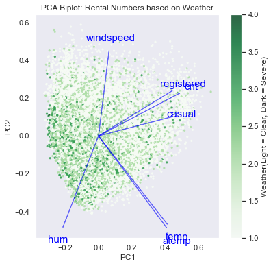

```python
def biplot(score,coeff,labels=None):
    xs = score[:,0]
    ys = score[:,1]
    n = coeff.shape[0]
    scalex = 1.0/(xs.max() - xs.min())
    scaley = 1.0/(ys.max() - ys.min())
    plt.scatter(xs * scalex,ys * scaley,s=5, c = hours.weathersit, alpha = 0.8, cmap = 'Greens', label = '1')
    plt.colorbar(label = 'Weather(Light = Clear, Dark = Severe)')
    plt.title('PCA Biplot: Rental Numbers based on Weather')
    for i in range(n):
        plt.arrow(0, 0, coeff[i,0], coeff[i,1],color = 'blue',alpha = 0.5)
        if labels is None:
            plt.text(coeff[i,0]* 1.15, coeff[i,1] * 1.15, "Var"+str(i+1), color = 'blue', ha = 'center', va = 'center', fontsize = 15)
        else:
            plt.text(coeff[i,0]* 1.15, coeff[i,1] * 1.15, labels[i], color = 'blue', ha = 'center', va = 'center', fontsize = 15)

    plt.xlabel("PC{}".format(1))
    plt.ylabel("PC{}".format(2))
    plt.grid()

plt.figure(figsize=(6, 6))
biplot(xpca, np.transpose(pca.components_), list(hours_X))
```

##### By creating the correlation plot below, we can take a closer look at how the total, casual, and registered rentals correlate with humidity. As predicted, there is a stronger correlation with casual rentals than with registered rentals.

```python
hum_df = hours[['hum', 'cnt', 'casual', 'registered']]
hum_df.corr()
```

|  | hum | cnt | casual | registered |
| --- | --- | --- | --- | --- |
| hum | 1.000000 | -0.322911 | -0.347028 | -0.273933 |
| cnt | -0.322911 | 1.000000 | 0.694564 | 0.972151 |
| casual | -0.347028 | 0.694564 | 1.000000 | 0.506618 |
| registered | -0.273933 | 0.972151 | 0.506618 | 1.000000 |

### Unsupervised Analysis:

##### We will use a kmeans classifier to classify our rentals by the weather conditions.

```python
X = hours[['cnt', 'registered', 'casual']]
y = hours['weathersit']

from sklearn.cluster import KMeans
kmeans = KMeans(n_clusters=4)
kmeans.fit(X)
y_pred = kmeans.predict(X)

from sklearn.metrics import accuracy_score
accuracy_score(y, y_pred)
```

```
0.1079463720582312
```

##### We can see that our accuracy score was quite low. Let's try classifying by the season instead.

```python
X = hours[['cnt', 'casual', 'registered']]
y = hours['season']

from sklearn.cluster import KMeans
kmeans = KMeans(n_clusters=4)
kmeans.fit(X)
y_pred = kmeans.predict(X)

from sklearn.metrics import accuracy_score
accuracy_score(y, y_pred)
```

```
0.14592324069279014
```

##### Once again, we see that the accuracy of our k means clustering is very low. Lets try classifying by workingdays and holidays instead and see if these have a higher accuracy score.

```python
X = hours[['cnt', 'casual', 'registered']]
y = hours['workingday']

from sklearn.cluster import KMeans
kmeans = KMeans(n_clusters=2)
kmeans.fit(X)
y_pred = kmeans.predict(X)

from sklearn.metrics import accuracy_score
accuracy_score(y, y_pred)
```

```
0.5831750963806893
```

```python
X = hours[['cnt', 'casual', 'registered']]
y = hours['holiday']

from sklearn.cluster import KMeans
kmeans = KMeans(n_clusters=2)
kmeans.fit(X)
y_pred = kmeans.predict(X)

accuracy_score(y, y_pred)
```

```
0.7192013349444732
```

##### Finally, we have a classifier with a high accuracy score. It appears that whether or not it is a holiday has a significant impact on the number of rentals.

### Supervised Analysis:

##### We will begin by using a k nearest neighbors classifier to predict whether it is a working day or not based on our rental numbers. We will then check the accuracy score of our model.

```python
X = hours[['cnt', 'casual', 'registered']]
y = hours['workingday']

from sklearn.neighbors import KNeighborsClassifier
model = KNeighborsClassifier(n_neighbors=2)

m = model.fit(X, y)
y_pred = model.predict(X)

from sklearn.metrics import accuracy_score
accuracy_score(y, y_pred)
```

```
0.7659243915069912
```

##### For working days, our accuracy score with our supervised model is much higher than the score we achieved with our unsupervised model. Now, we will perform a cross validation score in order to use unseen data in our prediction. We will perform a 10-fold cross validation and then compute the mean score.

```python
from sklearn.model_selection import cross_val_score
cv_score = cross_val_score(m, X, y, cv=10)
cv_score.mean()
```

```
0.634388748771906
```

##### Our cross validation score is less than our accuracy score, but still above 60%. Now, let's see how our supervised model performs when we use our rental numbers to predict whether it is a holiday or not.

```python
X = hours[['cnt', 'casual', 'registered']]
y = hours['holiday']

from sklearn.neighbors import KNeighborsClassifier
model = KNeighborsClassifier(n_neighbors=2)

m = model.fit(X, y)
y_pred = model.predict(X)

from sklearn.metrics import accuracy_score
accuracy_score(y, y_pred)
```

```
0.9718625927843949
```

```python
from sklearn.model_selection import cross_val_score
cv_score = cross_val_score(m, X, y, cv=10)
cv_score.mean()
```

```
0.9697909772612994
```

##### We can see that our supervised model gave a very high accuracy and cross validation score for the holiday classification.

##### Some of the variables we were originally interested in did not perform well in our unsupervised clustering. Let's see if they perform better using our supervised model. We'll start with the weather conditions.

```python
X = hours[['cnt', 'casual', 'registered']]
y = hours['weathersit']

from sklearn.neighbors import KNeighborsClassifier
model = KNeighborsClassifier(n_neighbors=4)

m = model.fit(X, y)
y_pred = model.predict(X)

from sklearn.metrics import accuracy_score
accuracy_score(y, y_pred)
```

```
0.6811093848898095
```

```python
from sklearn.model_selection import cross_val_score
cv_score = cross_val_score(m, X, y, cv=3)
cv_score.mean()
```

```
0.6017032050175498
```

##### It turns out that our supervised model has a much higher accuracy for the weather conditions. It seems as though this may be not be a poor predictor after all.

```python
X = hours[['cnt', 'casual', 'registered']]
y = hours['season']

from sklearn.neighbors import KNeighborsClassifier
model = KNeighborsClassifier(n_neighbors=4)

m = model.fit(X, y)
y_pred = model.predict(X)

from sklearn.metrics import accuracy_score
accuracy_score(y, y_pred)
```

```
0.5346682778065481
```

```python
from sklearn.model_selection import cross_val_score
cv_score = cross_val_score(m, X, y, cv=10)
cv_score.mean()
```

```
0.333503958056329
```

##### In contrast to our weather conditions model, the classification of season performed poorly in both our unsupervised and supervised models. It would seem that there are better ways to predict our bike rental sales.

### Conclusion:

##### We began our analysis by exploring the bike rentals dataset. During our exploration, we chose to focus on an area with potential to create value. We then created some exploratory plots in order to better visualize the relationships between the different variables within our data. We then took a closer look into these relationships by implementing both unsupervised and supervised classification methods. In the end, we found that some variables were better at predicting rentals than others.

##### Through our analysis, we saw that there were some correlations between humidity and the number of rentals. We also saw through various forms of machine learning that some of our best predictors were weather conditions, whether or not it was a holiday, and whether or not it was a working day. On the other hand, we noticed that other variables, such as the season, were not as strong at predicting our rental numbers.

##### We can draw some real world considerations from this analysis. First off, it appears that weather conditions have a stronger affect on rental numbers than the time of the year. This may present an opportunity to market rentals deeper into the off-seasons if the weather remains decent. Another consideration is that there are fewer overall casual rentals in comparison to registered rentals. In addition, the number of rentals do seem to fluctuate with the time of the day, as well as with holidays and working days. We may be able to use this information to our advantage in order to market and push casual rentals during times when registered rentals are at their lowest points, as there will be more bikes available for use.